# Data Mining Homework1(Building_Permits.csv)

Dealing with missing data:omitting missing value. This can be achieve using following script(take the Proposed.Units as an example). It’s obvious that this move does not change the visualization of a given attribute.

```r
summary(na.omit(b_p[["Proposed.Units"]]))
```

```
##    Min. 1st Qu.  Median    Mean 3rd Qu.    Max.
##    0.00    1.00    2.00   16.51    4.00 1911.00
```

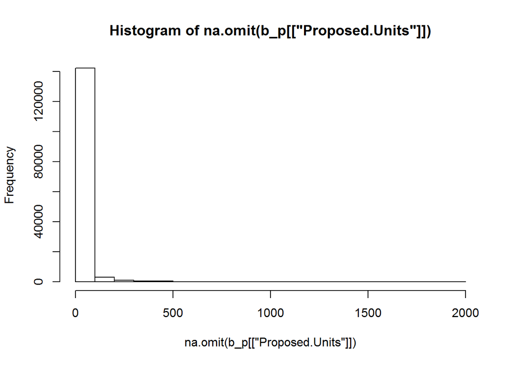

```r
hist(na.omit(b_p[["Proposed.Units"]]))
```

Dealing with missing data: filling NA with value of largest frequency. When dealing with nominal attributes, take “Proposed.Construction.Type” as an example.

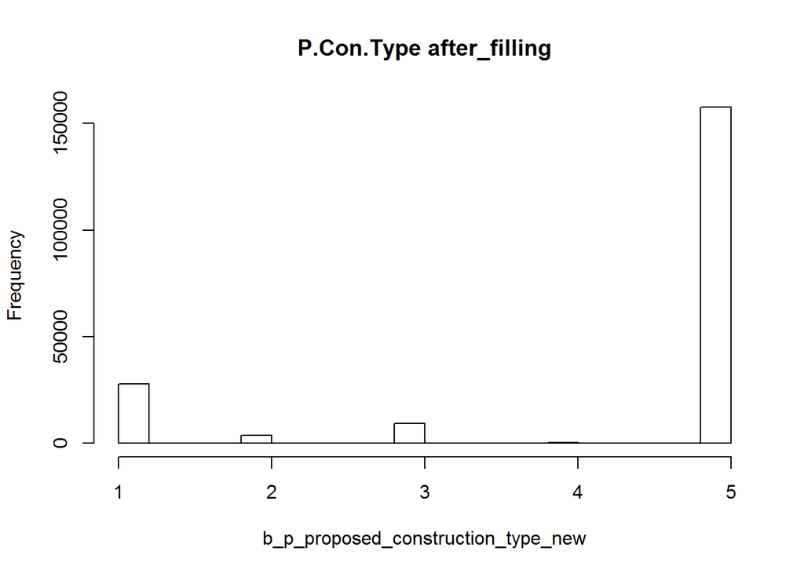

```r
b_p_proposed_construction_type_new<-b_p[["Proposed.Construction.Type"]]
b_p_proposed_construction_type_new[is.na(b_p_proposed_construction_type_new)]<-plyr::count(b_p_proposed_construction_type_new)$x[which.max(plyr::count(b_p_proposed_construction_type_new)$freq)]
hist(b_p_proposed_construction_type_new,main="P.Con.Type after_filling")
```

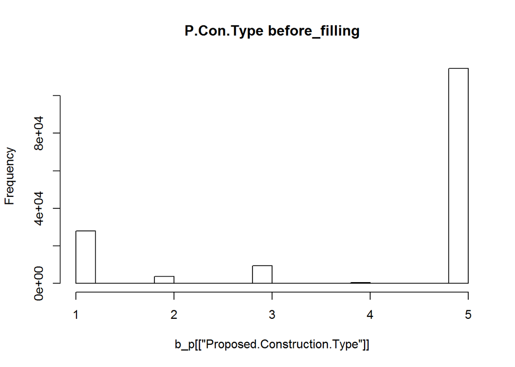

```r
hist(b_p[["Proposed.Construction.Type"]],main="P.Con.Type before_filling")
```

As for numeric attributes, the script below is used. Unit

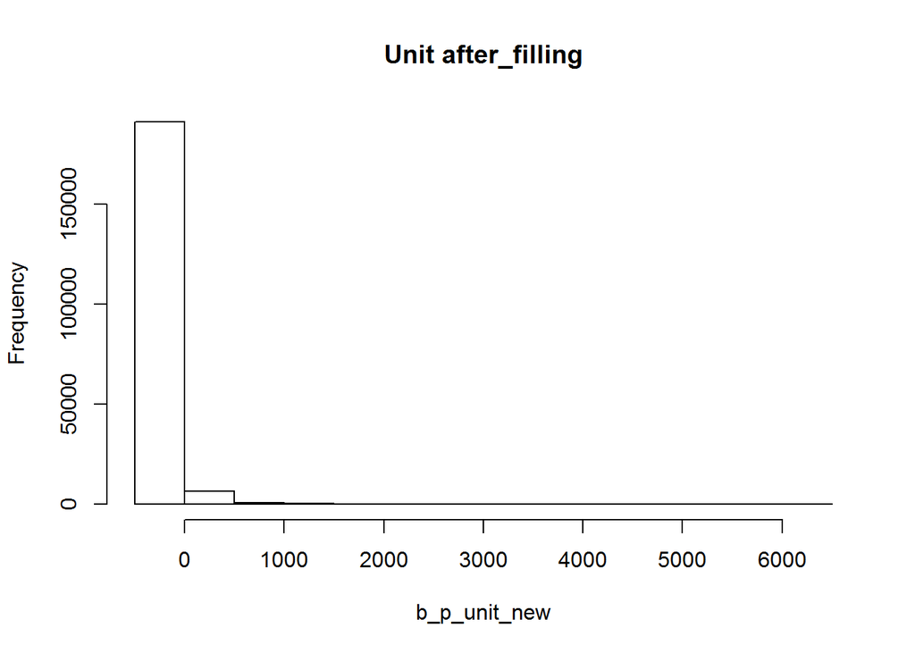

```r
b_p_unit_new<-b_p[["Unit"]]
temp=density(na.omit(b_p[["Unit"]]),bw=1)
b_p_unit_new[which(is.na(b_p_unit_new))]<-temp$x[which.max(temp$y)]
hist(b_p_unit_new,main="Unit after_filling")
```

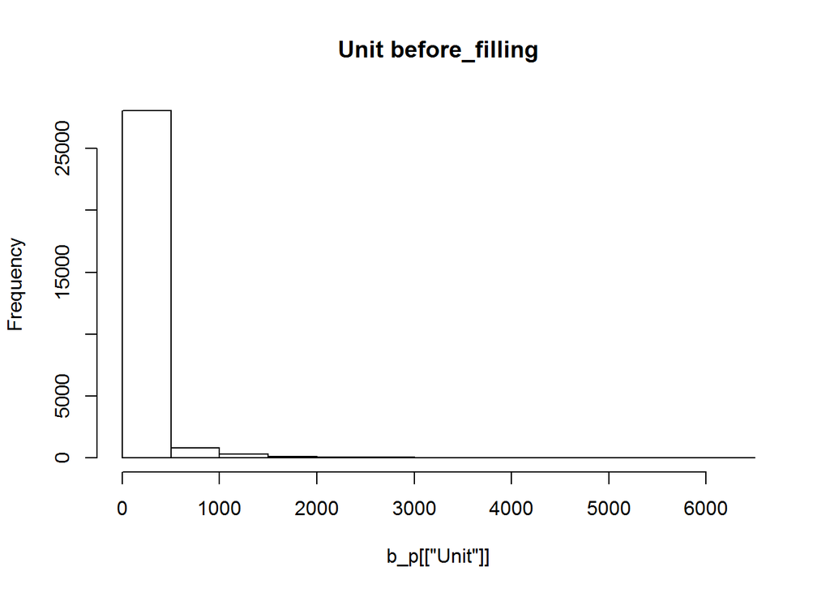

```r
hist(b_p[["Unit"]],main="Unit before_filling")
```

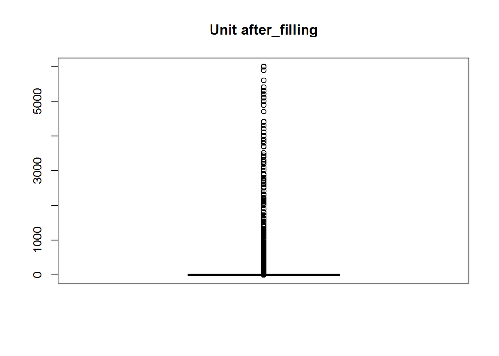

```r
boxplot(b_p_unit_new,main="Unit after_filling")
```

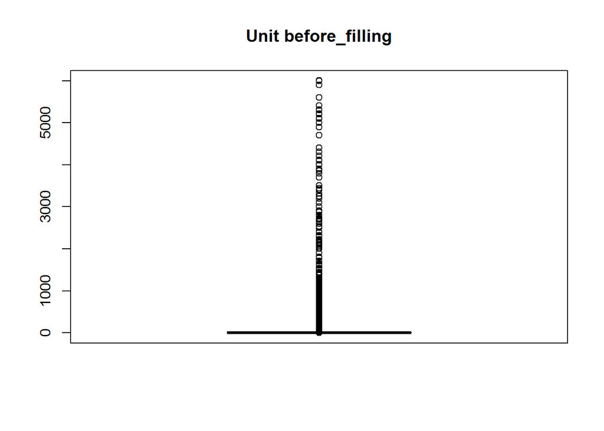

```r
boxplot(b_p[["Unit"]],main="Unit before_filling")
```

Number.of.Existing.Stories

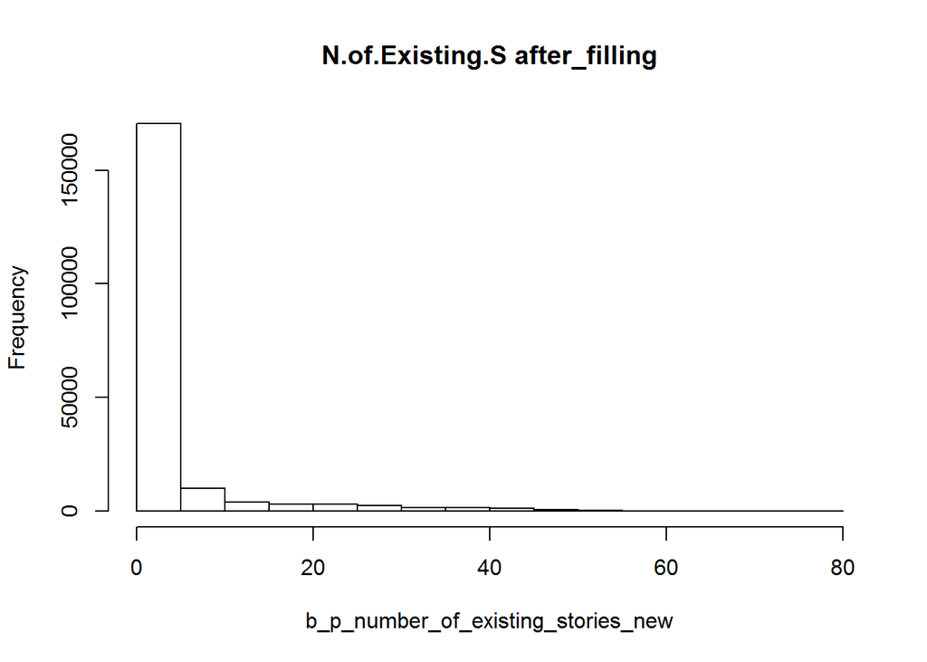

```r
b_p_number_of_existing_stories_new<-b_p[["Number.of.Existing.Stories"]]
temp=density(na.omit(b_p[["Number.of.Existing.Stories"]]),bw=1)
b_p_number_of_existing_stories_new[which(is.na(b_p_number_of_existing_stories_new))]<-temp$x[which.max(temp$y)]
hist(b_p_number_of_existing_stories_new,main="N.of.Existing.S after_filling")
```

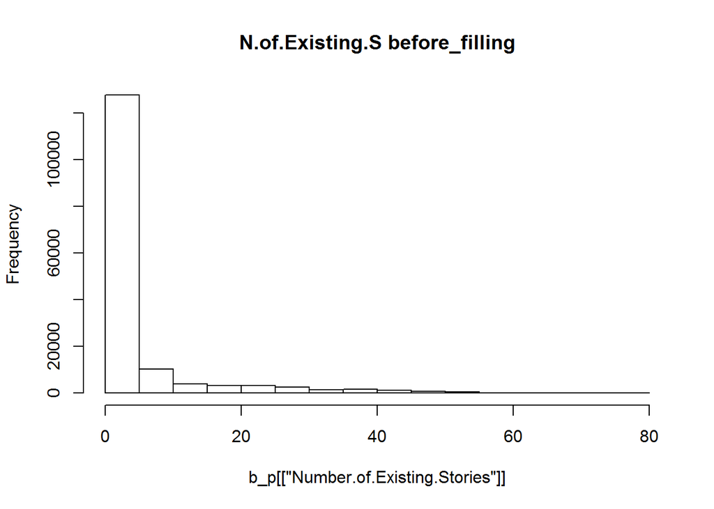

```r
hist(b_p[["Number.of.Existing.Stories"]],main="N.of.Existing.S before_filling")
```

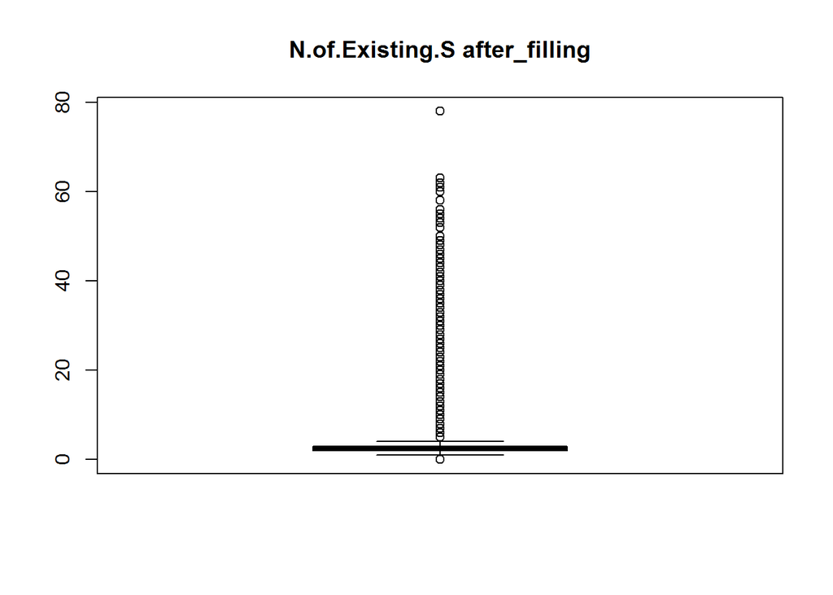

```r
boxplot(b_p_number_of_existing_stories_new,main="N.of.Existing.S after_filling")
```

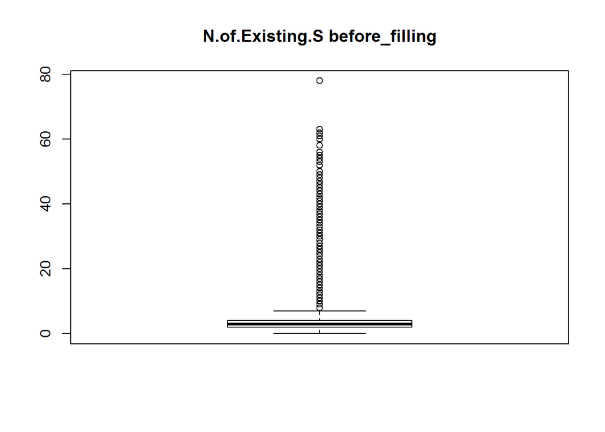

```r
boxplot(b_p[["Number.of.Existing.Stories"]],main="N.of.Existing.S before_filling")
```

Number.of.Proposed.Stories

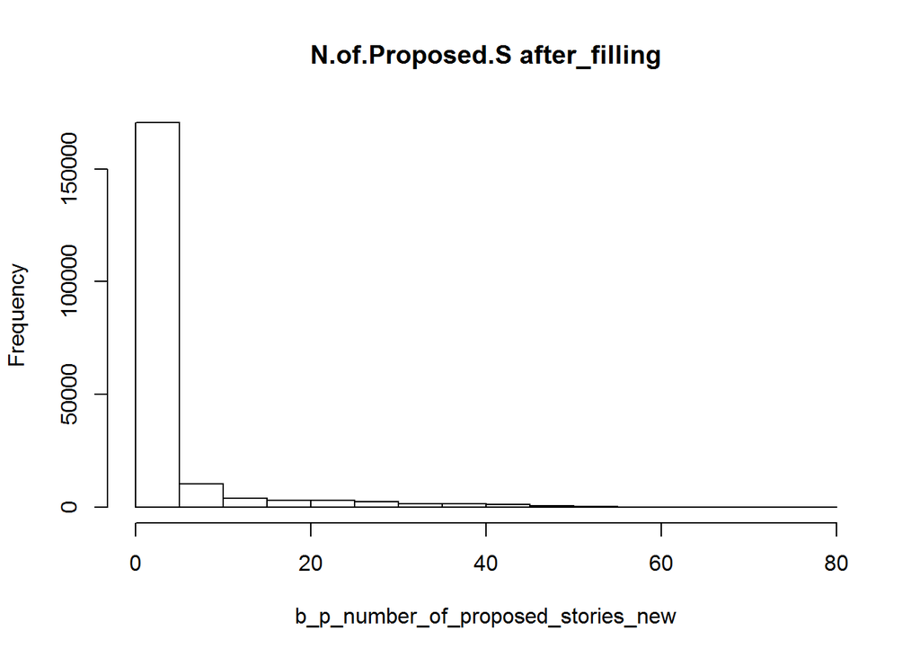

```r
b_p_number_of_proposed_stories_new<-b_p[["Number.of.Proposed.Stories"]]
temp=density(na.omit(b_p[["Number.of.Proposed.Stories"]]),bw=1)
b_p_number_of_proposed_stories_new[which(is.na(b_p[["Number.of.Proposed.Stories"]]))]<-temp$x[which.max(temp$y)]
hist(b_p_number_of_proposed_stories_new,main="N.of.Proposed.S after_filling")
```

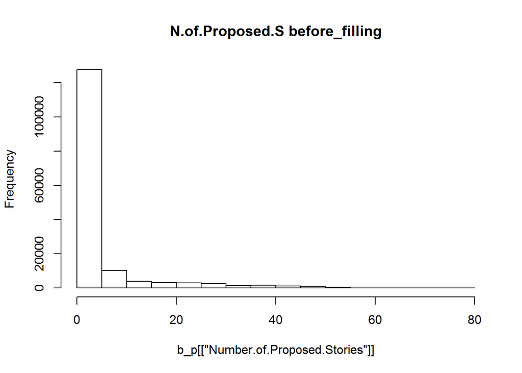

```r
hist(b_p[["Number.of.Proposed.Stories"]],main="N.of.Proposed.S before_filling")
```

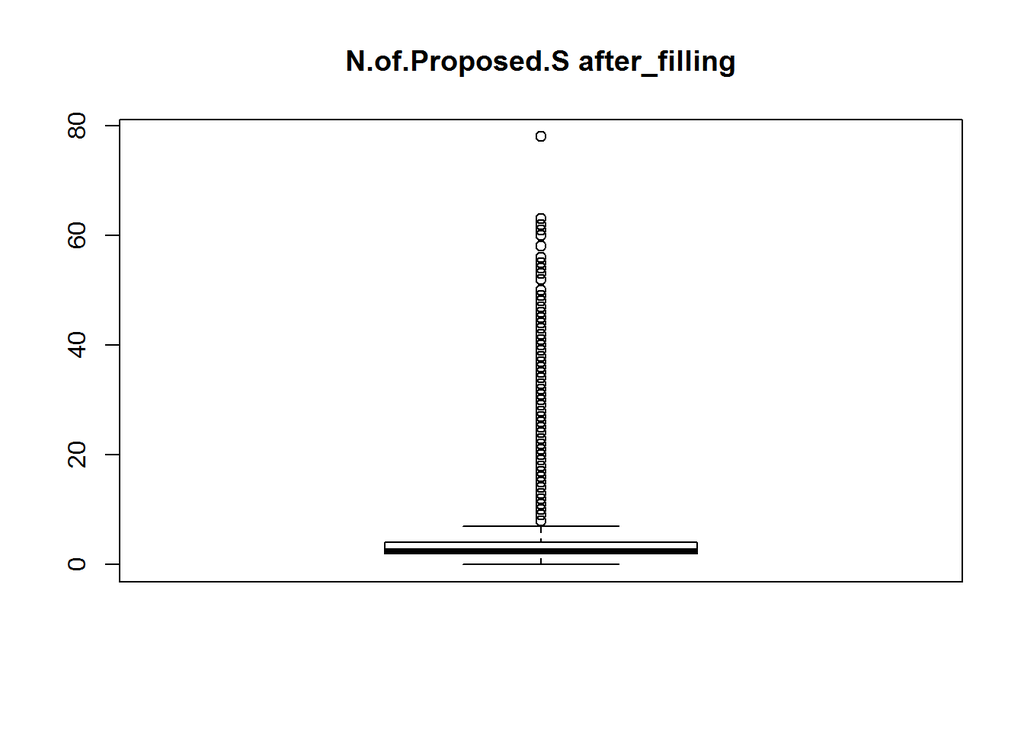

```r
boxplot(b_p_number_of_proposed_stories_new,main="N.of.Proposed.S after_filling")
```

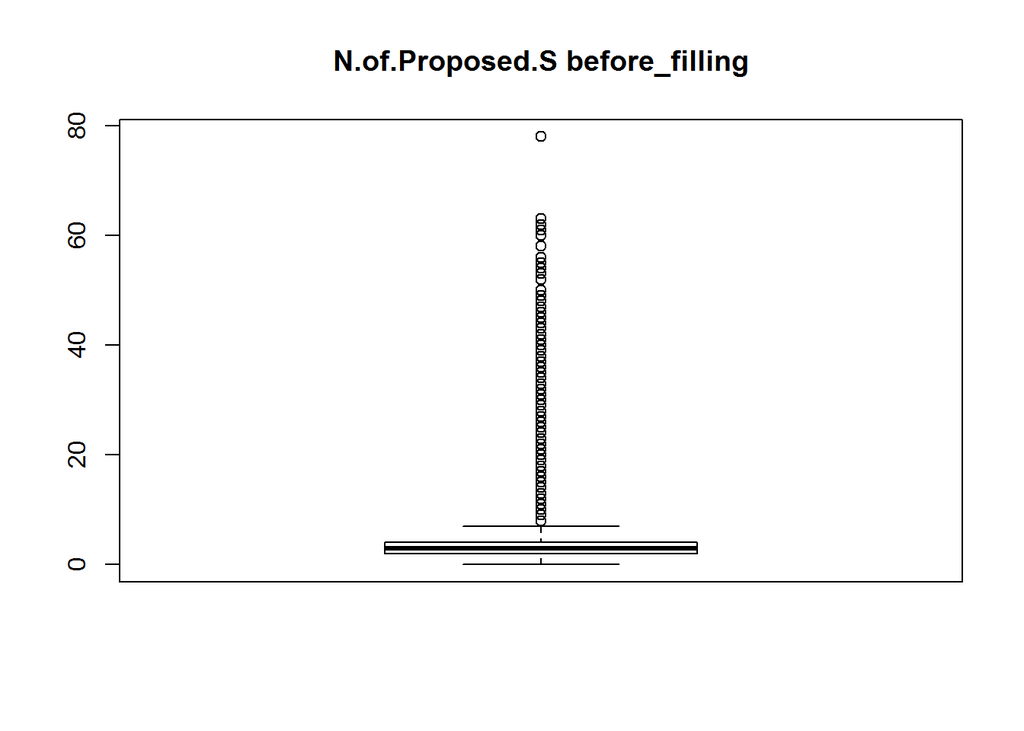

```r
boxplot(b_p[["Number.of.Proposed.Stories"]],main="N.of.Proposed.S before_filling")
```

Existing.Units

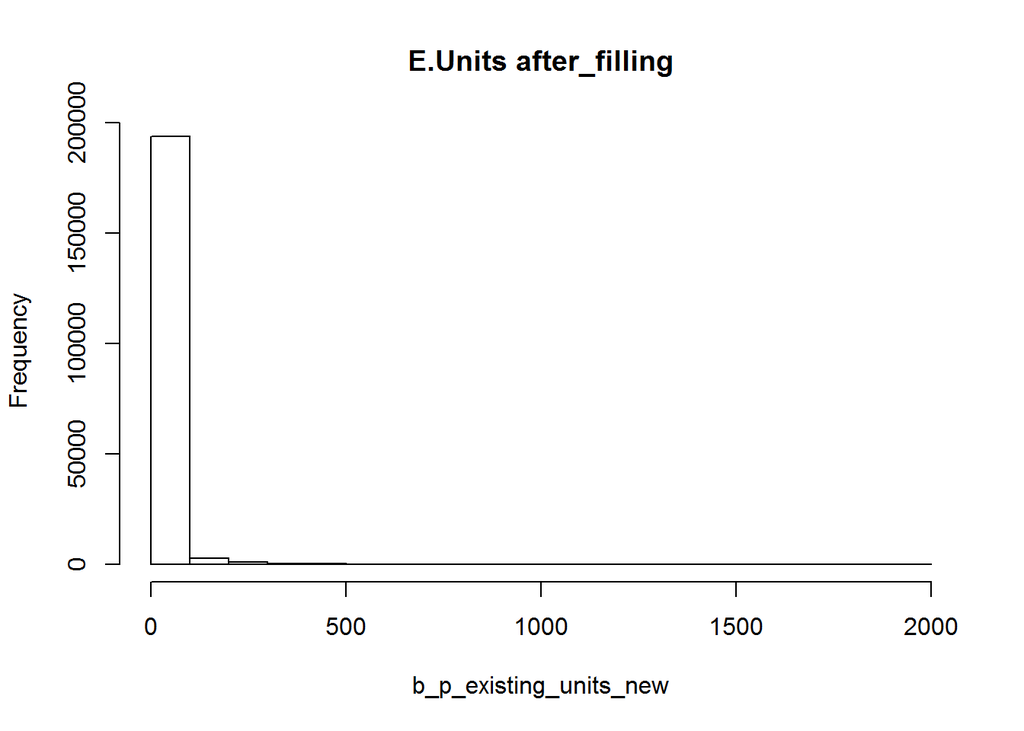

```r
b_p_existing_units_new<-b_p[["Existing.Units"]]
temp=density(na.omit(b_p[["Existing.Units"]]),bw=1)
b_p_existing_units_new[which(is.na(b_p_existing_units_new))]<-temp$x[which.max(temp$y)]
hist(b_p_existing_units_new,main="E.Units after_filling")
```

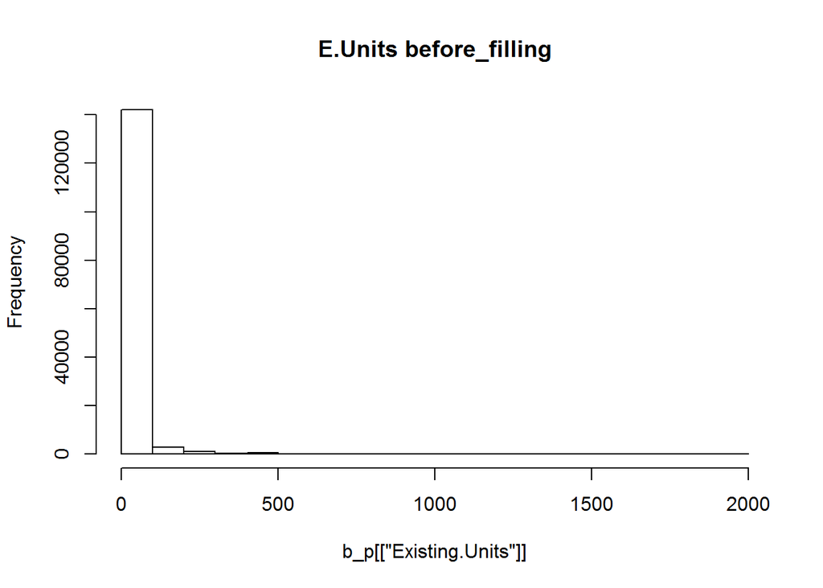

```r
hist(b_p[["Existing.Units"]],main="E.Units before_filling")
```

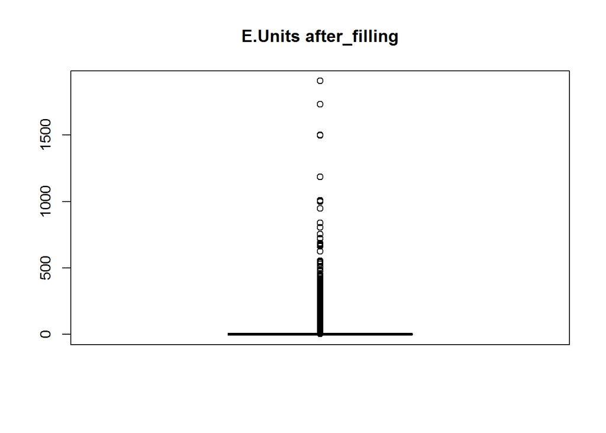

```r
boxplot(b_p_existing_units_new,main="E.Units after_filling")
```

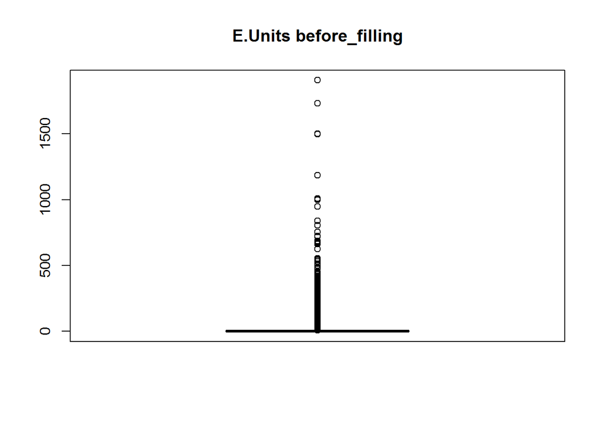

```r
boxplot(b_p[["Existing.Units"]],main="E.Units before_filling")
```

Proposed.Units

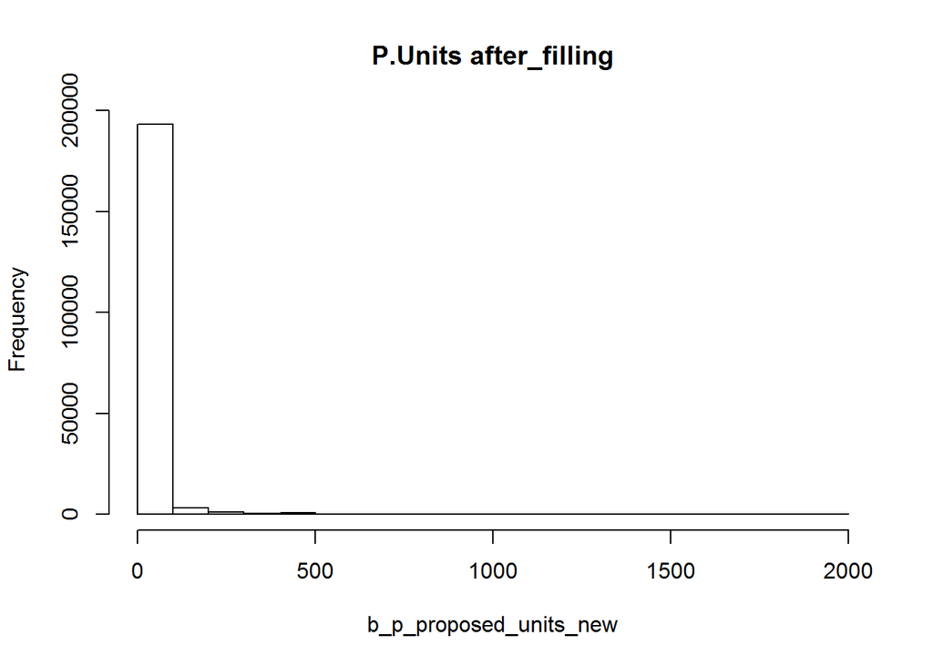

```r
b_p_proposed_units_new<-b_p[["Proposed.Units"]]
temp=density(na.omit(b_p[["Proposed.Units"]]),bw=1)
b_p_proposed_units_new[which(is.na(b_p_proposed_units_new))]<-temp$x[which.max(temp$y)]
hist(b_p_proposed_units_new,main="P.Units after_filling")
```

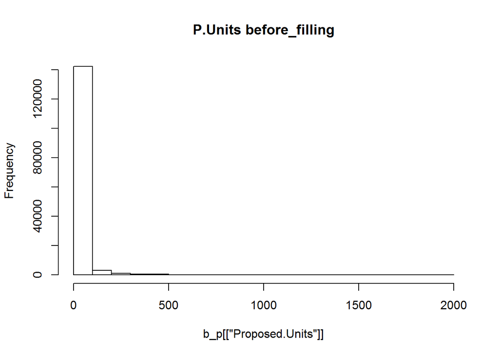

```r
hist(b_p[["Proposed.Units"]],main="P.Units before_filling")
```

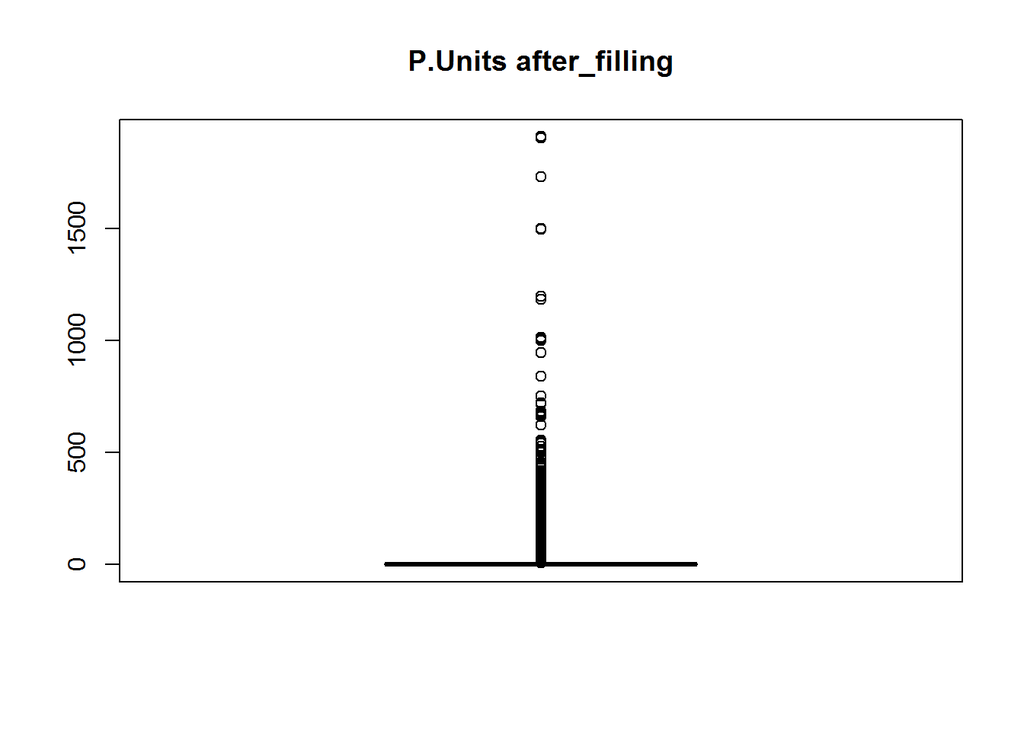

```r
boxplot(b_p_proposed_units_new,main="P.Units after_filling")
```

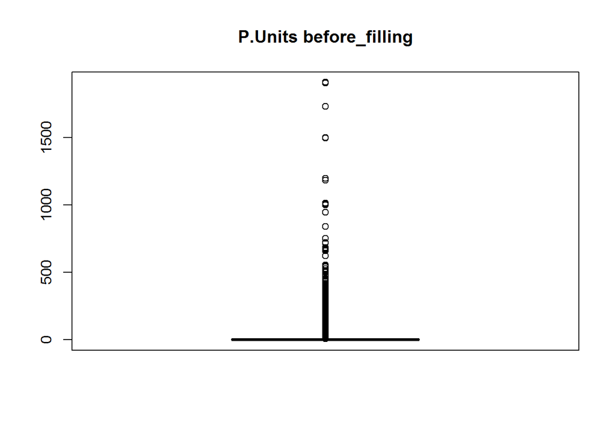

```r
boxplot(b_p[["Proposed.Units"]],main="P.Units before_filling")
```

b_p_cost

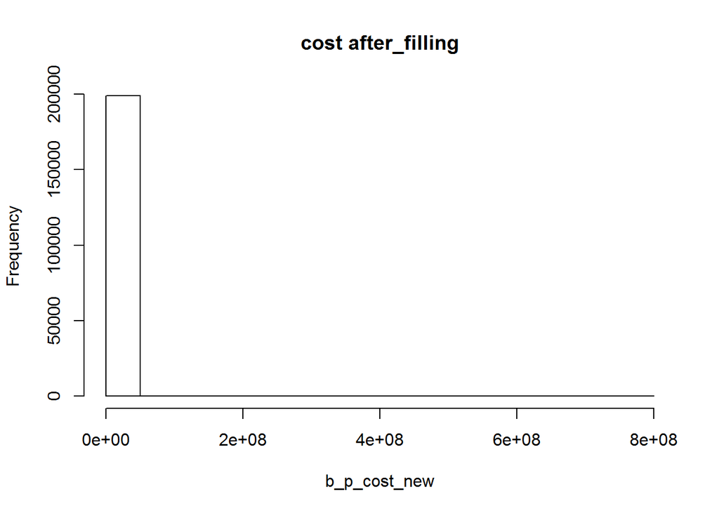

```r
b_p_cost_new<-b_p_cost
temp=density(na.omit(b_p_cost),bw=1)
b_p_cost_new[which(is.na(b_p_cost_new))]<-temp$x[which.max(temp$y)]
hist(b_p_cost_new,main="cost after_filling")
```

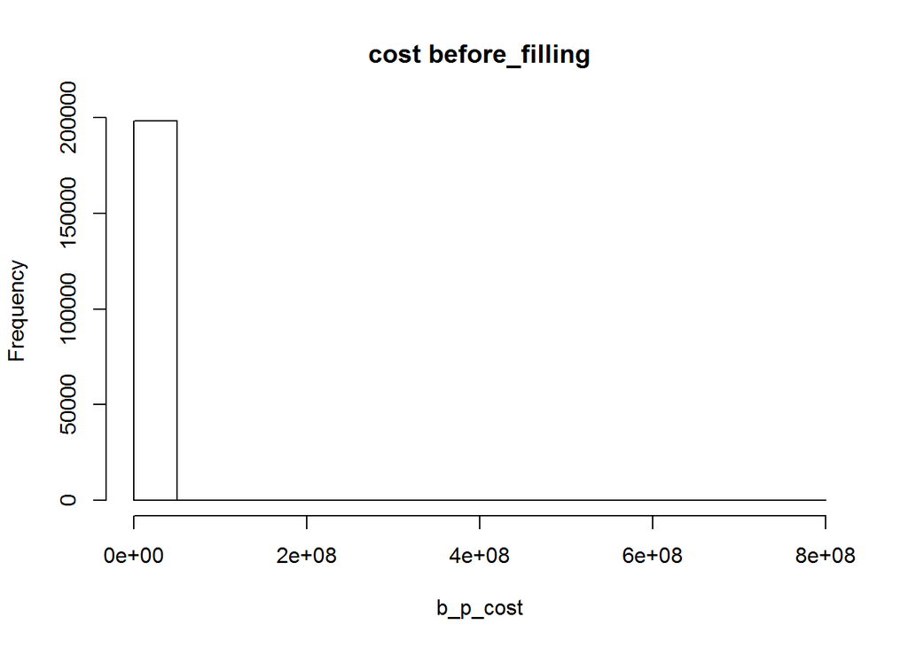

```r
hist(b_p_cost,main="cost before_filling")
```

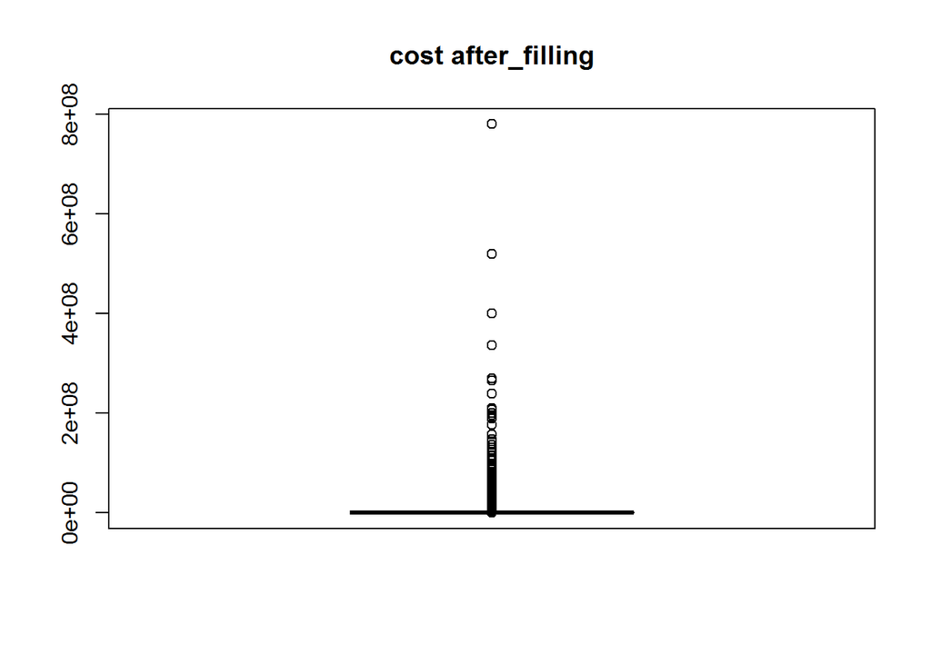

```r
boxplot(b_p_cost_new,main="cost after_filling")
```

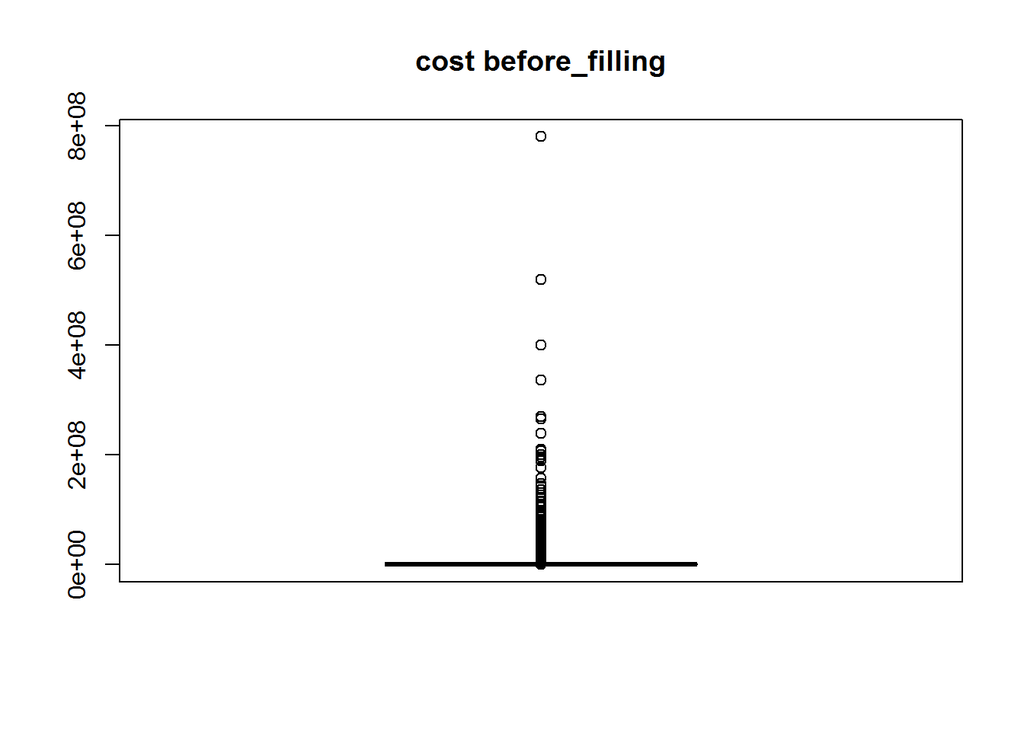

```r
boxplot(b_p_cost,main="cost before_filling")
```

Before using some “advanced” method to fill NA values, we must have a closer look at the data set. At first, we should know the number of types of permits and the features of each one.

```r
count(b_p[["Permit.Type"]])
```

| x | freq |
| --- | --- |
| 1 | 349 |
| 2 | 950 |
| 3 | 14663 |
| 4 | 2892 |
| 5 | 91 |
| 6 | 600 |
| 7 | 511 |
| 8 | 178844 |

Type1: new construction, “Existing.Units” and “Number.of.Existing.Units” should be NA, “Unit” should be 0. Type2: new construction wood frame, “Units” and “Existing.Units” should be 0. Type3: additional alterations or repairs, nothing special. Type4: sign-erect, “Number.of.Proposed.Stories” and “Proposed.Units” should be 0. Type5: grade or quarry or fill or excavate, “Number.of.Existing.Stories” and “Number.of.Proposed.Stories” should be NA, “Existing.Units”, “Proposed.Units” and “Unit” should be 0. Type6: demolitions, “Unit” should be 0, “Number.of.Proposed.Stories” and “Proposed.Units” should be NA. Type7:wall or painted sign, “Number.of.Proposed.Stories” and “Proposed.Units” should be NA, “Existing.Units” should be 0. Type8: otc alterations permits, nothing special.

Divide the numeric part of the data.frame by type.

```r
b_p_missing_numeric_with_type<-select(b_p,Permit.Type,Unit,Number.of.Existing.Stories,Number.of.Proposed.Stories,Existing.Units,Proposed.Units)
b_p_missing_numeric_with_type<-cbind(b_p_cost,b_p_missing_numeric_with_type)
b_p_numeric_type1<-b_p_missing_numeric_with_type[which(b_p_missing_numeric_with_type[["Permit.Type"]]==1),]
b_p_numeric_type2<-b_p_missing_numeric_with_type[which(b_p_missing_numeric_with_type[["Permit.Type"]]==2),]
b_p_numeric_type3<-b_p_missing_numeric_with_type[which(b_p_missing_numeric_with_type[["Permit.Type"]]==3),]
b_p_numeric_type4<-b_p_missing_numeric_with_type[which(b_p_missing_numeric_with_type[["Permit.Type"]]==4),]
b_p_numeric_type5<-b_p_missing_numeric_with_type[which(b_p_missing_numeric_with_type[["Permit.Type"]]==5),]
b_p_numeric_type6<-b_p_missing_numeric_with_type[which(b_p_missing_numeric_with_type[["Permit.Type"]]==6),]
b_p_numeric_type7<-b_p_missing_numeric_with_type[which(b_p_missing_numeric_with_type[["Permit.Type"]]==7),]
b_p_numeric_type8<-b_p_missing_numeric_with_type[which(b_p_missing_numeric_with_type[["Permit.Type"]]==8),]
```

Use correlation among attributes to fill NA values. Package “mice” is introduced and it’s used for imputing.

```r
library(mice)
```

Type 1

```r
symnum(cor(b_p_numeric_type1[,c(1,5,7)],use="complete.obs"))
```

```
##                            b N P
## b_p_cost                   1
## Number.of.Proposed.Stories + 1
## Proposed.Units             , . 1
## attr(,"legend")
## [1] 0 ' ' 0.3 '.' 0.6 ',' 0.8 '+' 0.9 '*' 0.95 'B' 1
```

There exist some data which all there meaningful attributes are missed. It’s reasonably to discard them.

```r
library(DMwR)
b_p_numeric_type1_1<-b_p_numeric_type1[-manyNAs(b_p_numeric_type1[,c(1,5,7)],0.68),]
```

According to the correlation matrix, there is a strong linear relationship between b_p_cost and Number.of.Proposed.Stories as well as between b_p_cost and Proposed.Units. So two linear models are fitted.

```r
lm(Number.of.Proposed.Stories~b_p_cost,data=b_p_numeric_type1_1)
```

```
##
## Call:
## lm(formula = Number.of.Proposed.Stories ~ b_p_cost, data = b_p_numeric_type1_1)
##
## Coefficients:
## (Intercept)     b_p_cost
##   5.070e+00    9.293e-08
```

```r
lm(Proposed.Units~b_p_cost,data=b_p_numeric_type1_1)
```

```
##
## Call:
## lm(formula = Proposed.Units ~ b_p_cost, data = b_p_numeric_type1_1)
##
## Coefficients:
## (Intercept)     b_p_cost
##   4.959e+01    1.170e-06
```

Using the fitted models to fill NA values.

```r
b_p_numeric_type1_new<-b_p_numeric_type1_1
b_p_numeric_type1_new[which(is.na(b_p_numeric_type1_new[["Number.of.Proposed.Stories"]])),"Number.of.Proposed.Stories"]<-floor((9.293e-8)*b_p_numeric_type1_new[which(is.na(b_p_numeric_type1_new[["Number.of.Proposed.Stories"]])),"b_p_cost"]+5.07)

b_p_numeric_type1_new[which(is.na(b_p_numeric_type1_new[["Proposed.Units"]])),"Proposed.Units"]<-floor((1.17e-6)*b_p_numeric_type1_new[which(is.na(b_p_numeric_type1_new[["Proposed.Units"]])),"b_p_cost"]+49.59)

#b_p_numeric_type1_new<-select(b_p_numeric_type1_new,b_p_cost,Unit,Number.of.Existing.Stories,Number.of.Proposed.Stories,Existing.Units,Proposed.Units)
```

Type2

```r
symnum(cor(b_p_numeric_type2[,c(1,5,7)],use="complete.obs"))
```

```
##                            b N P
## b_p_cost                   1
## Number.of.Proposed.Stories . 1
## Proposed.Units             B . 1
## attr(,"legend")
## [1] 0 ' ' 0.3 '.' 0.6 ',' 0.8 '+' 0.9 '*' 0.95 'B' 1
```

```r
tempData_type2 <- mice( b_p_numeric_type2[,c(1,5,7)] ,m=3,maxit=10,meth="pmm")
completedData <- complete(tempData_type2,1)
#completedData[["Unit"]]<-floor(completedData[["Units"]])
#completedData[["Number.of.Existing.Stories"]]<-floor(completedData[["Number.of.Existing.Stories"]])
completedData[["Number.of.Proposed.Stories"]]<-floor(completedData[["Number.of.Proposed.Stories"]])
#completedData[["Existing.Units"]]<-floor(completedData[["Existing.Units"]])
#completedData[["Proposed.Units"]]<-floor(completedData[["Proposed.Units"]])

b_p_numeric_type2_new<-b_p_numeric_type2
b_p_numeric_type2_new[,c(1,5,7)]<-completedData
summary(completedData)
```

```
##     b_p_cost         Number.of.Proposed.Stories Proposed.Units
##  Min.   :        1   Min.   :0.000              Min.   :  0.000
##  1st Qu.:   498485   1st Qu.:3.000              1st Qu.:  1.000
##  Median :   710212   Median :3.000              Median :  2.000
##  Mean   :  2122824   Mean   :3.165              Mean   :  6.187
##  3rd Qu.:  1280718   3rd Qu.:4.000              3rd Qu.:  3.000
##  Max.   :123000000   Max.   :6.000              Max.   :408.000
```

Type3

```r
symnum(cor(b_p_numeric_type3[,c(1,3,4,5,6,7)],use="complete.obs"))
```

```
##                            b U N..E N..P E P
## b_p_cost                   1
## Unit                         1
## Number.of.Existing.Stories     1
## Number.of.Proposed.Stories     B    1
## Existing.Units                 ,    ,    1
## Proposed.Units                 ,    ,    B 1
## attr(,"legend")
## [1] 0 ' ' 0.3 '.' 0.6 ',' 0.8 '+' 0.9 '*' 0.95 'B' 1
```

```r
tempData_type3 <- mice( b_p_numeric_type3[,c(1,3,4,5,6,7)] ,m=3,maxit=10,meth="pmm")
completedData <- complete(tempData_type3,1)
#completedData[["Unit"]]<-floor(completedData[["Units"]])
completedData[["Number.of.Existing.Stories"]]<-floor(completedData[["Number.of.Existing.Stories"]])
completedData[["Number.of.Proposed.Stories"]]<-floor(completedData[["Number.of.Proposed.Stories"]])
completedData[["Existing.Units"]]<-floor(completedData[["Existing.Units"]])
completedData[["Proposed.Units"]]<-floor(completedData[["Proposed.Units"]])

b_p_numeric_type3_new<-b_p_numeric_type3
b_p_numeric_type3_new[,c(1,3,4,5,6,7)]<-completedData
summary(completedData)
```

```
##     b_p_cost              Unit         Number.of.Existing.Stories
##  Min.   :        0   Min.   :   0.00   Min.   : 0.000
##  1st Qu.:    22000   1st Qu.:   0.00   1st Qu.: 2.000
##  Median :    80000   Median :   0.00   Median : 3.000
##  Mean   :   459710   Mean   :  34.93   Mean   : 4.071
##  3rd Qu.:   274500   3rd Qu.:   0.00   3rd Qu.: 4.000
##  Max.   :266061486   Max.   :3510.00   Max.   :63.000
##  Number.of.Proposed.Stories Existing.Units    Proposed.Units
##  Min.   : 0.000             Min.   :   0.00   Min.   :   0.00
##  1st Qu.: 2.000             1st Qu.:   1.00   1st Qu.:   1.00
##  Median : 3.000             Median :   2.00   Median :   2.00
##  Mean   : 4.263             Mean   :  17.42   Mean   :  18.61
##  3rd Qu.: 4.000             3rd Qu.:   6.00   3rd Qu.:   6.00
##  Max.   :63.000             Max.   :1907.00   Max.   :1907.00
```

Type4

```r
symnum(cor(b_p_numeric_type4[,c(1,3,4,6)],use="complete.obs"))
```

```
##                            b U N E
## b_p_cost                   1
## Unit                       . 1
## Number.of.Existing.Stories     1
## Existing.Units                 . 1
## attr(,"legend")
## [1] 0 ' ' 0.3 '.' 0.6 ',' 0.8 '+' 0.9 '*' 0.95 'B' 1
```

```r
tempData_type4 <- mice( b_p_numeric_type4[,c(1,3,4,6)] ,m=3,maxit=10,meth="pmm")
completedData <- complete(tempData_type4,1)
#completedData[["Unit"]]<-floor(completedData[["Units"]])
completedData[["Number.of.Existing.Stories"]]<-floor(completedData[["Number.of.Existing.Stories"]])
#completedData[["Number.of.Proposed.Stories"]]<-floor(completedData[["Number.of.Proposed.Stories"]])
completedData[["Existing.Units"]]<-floor(completedData[["Existing.Units"]])
#completedData[["Proposed.Units"]]<-floor(completedData[["Proposed.Units"]])

b_p_numeric_type4_new<-b_p_numeric_type4
b_p_numeric_type4_new[,c(1,3,4,6)]<-completedData
summary(completedData)
```

```
##     b_p_cost           Unit         Number.of.Existing.Stories
##  Min.   :     1   Min.   :   0.00   Min.   : 0.000
##  1st Qu.:  1500   1st Qu.:   0.00   1st Qu.: 2.000
##  Median :  3000   Median :   0.00   Median : 3.000
##  Mean   :  4824   Mean   :  15.43   Mean   : 6.773
##  3rd Qu.:  5000   3rd Qu.:   0.00   3rd Qu.: 7.000
##  Max.   :250000   Max.   :2214.00   Max.   :63.000
##  Existing.Units
##  Min.   :   0.00
##  1st Qu.:   0.00
##  Median :   0.00
##  Mean   :  26.72
##  3rd Qu.:   0.00
##  Max.   :1500.00
```

Type5, as it is described before, its only meaningful attribute is the “b_p_cost”.

```r
count(is.na(b_p_numeric_type5[["b_p_cost"]]))
```

| x | freq |
| --- | --- |
| FALSE | 91 |

Type5 does not need NA filling.

```r
b_p_numeric_type5_new<-b_p_numeric_type5
```

Type6

```r
symnum(cor(b_p_numeric_type6[,c(1,4,6)],use="complete.obs"))
```

```
##                            b N E
## b_p_cost                   1
## Number.of.Existing.Stories . 1
## Existing.Units                 1
## attr(,"legend")
## [1] 0 ' ' 0.3 '.' 0.6 ',' 0.8 '+' 0.9 '*' 0.95 'B' 1
```

```r
tempData_type6 <- mice( b_p_numeric_type6[,c(1,4,6)] ,m=3,maxit=10,meth="pmm")
completedData <- complete(tempData_type6,1)
#completedData[["Unit"]]<-floor(completedData[["Units"]])
completedData[["Number.of.Existing.Stories"]]<-floor(completedData[["Number.of.Existing.Stories"]])
#completedData[["Number.of.Proposed.Stories"]]<-floor(completedData[["Number.of.Proposed.Stories"]])
completedData[["Existing.Units"]]<-floor(completedData[["Existing.Units"]])
#completedData[["Proposed.Units"]]<-floor(completedData[["Proposed.Units"]])

b_p_numeric_type6_new<-b_p_numeric_type6
b_p_numeric_type6_new[,c(1,4,6)]<-completedData
summary(completedData)
```

```
##     b_p_cost       Number.of.Existing.Stories Existing.Units
##  Min.   :      1   Min.   :1.0                Min.   : 0.0000
##  1st Qu.:  10000   1st Qu.:1.0                1st Qu.: 0.0000
##  Median :  20000   Median :2.0                Median : 0.0000
##  Mean   :  95168   Mean   :1.7                Mean   : 0.9317
##  3rd Qu.:  65000   3rd Qu.:2.0                3rd Qu.: 1.0000
##  Max.   :6300000   Max.   :9.0                Max.   :24.0000
```

Type7

```r
symnum(cor(b_p_numeric_type7[,c(1,3)],use="complete.obs"))
```

```
##          b U
## b_p_cost 1
## Unit       1
## attr(,"legend")
## [1] 0 ' ' 0.3 '.' 0.6 ',' 0.8 '+' 0.9 '*' 0.95 'B' 1
```